# Data Science - Scientific Computing in Python

Free eBook: https://pythonnumericalmethods.berkeley.edu/notebooks/Index.html

Citation:

(1) School of Computing - Statistical Data Analytics, University of California at Berkeley, Berkeley, CA 94720-1786

(2) Brad Nelson, Computational Topology, University of Chicago, Chicago

### Topics:

```
1. Matrix Fundamentals
2. Distance Metrics
3. Sparse Matrix Operations
4. Week 3 Assignment Hints and Tricks
```

## 1. Matrix Fundamentals

All about Matrices:

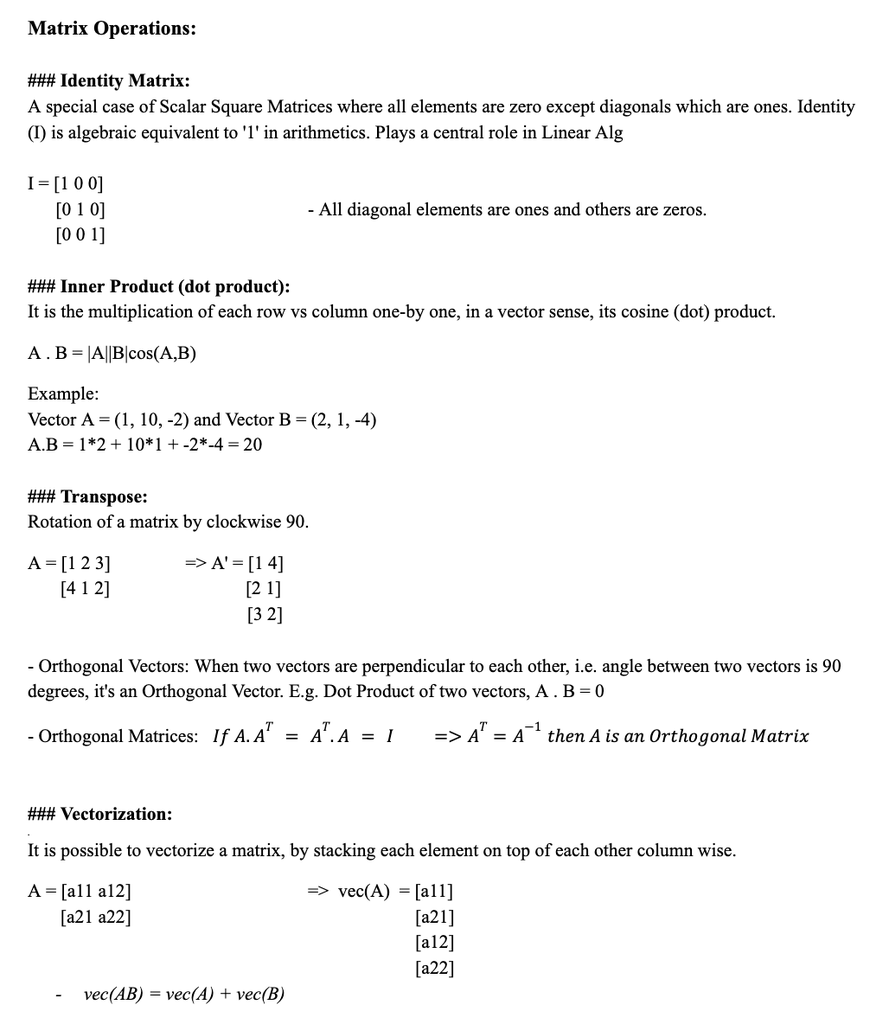

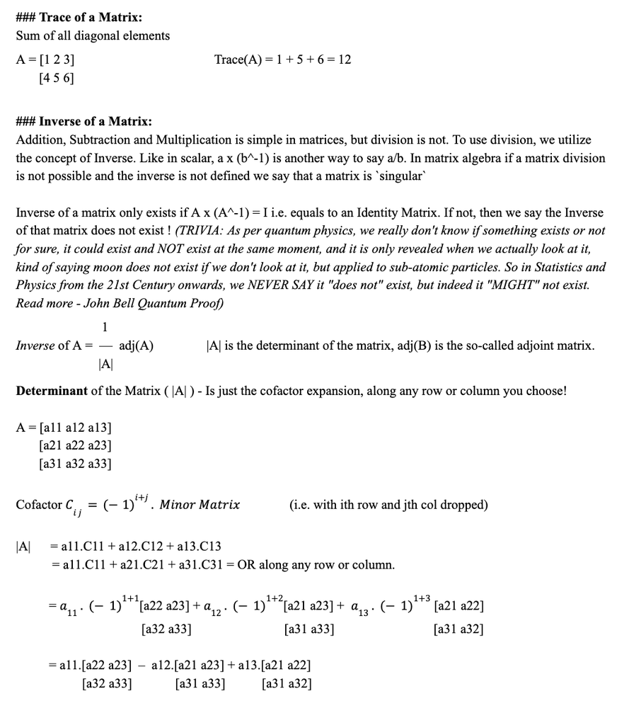

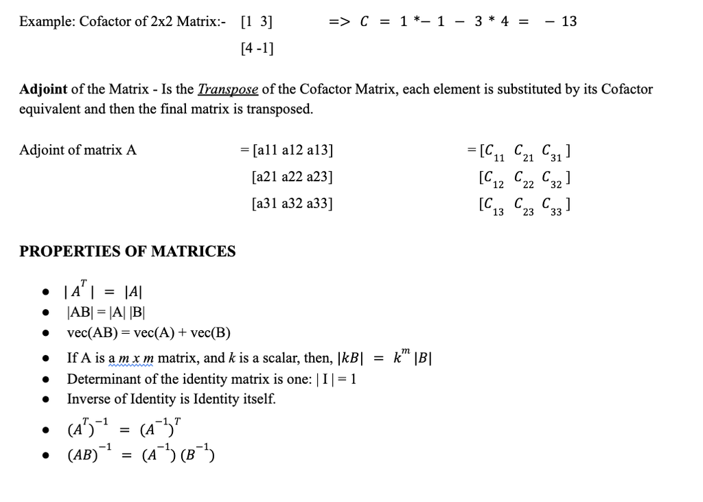

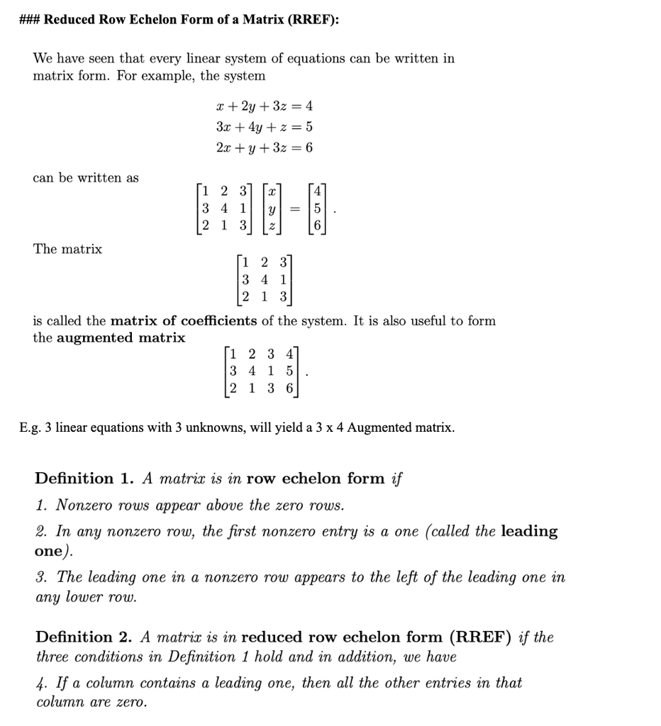

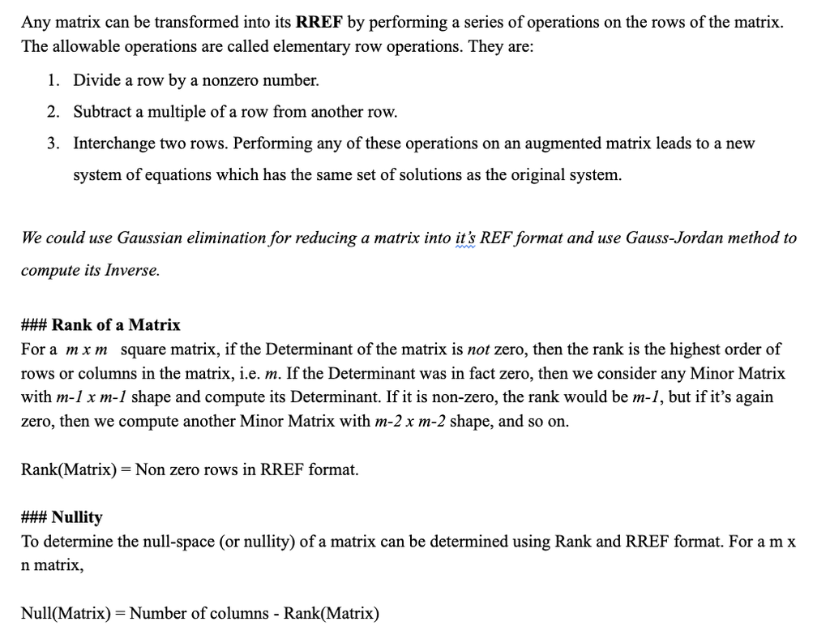

## 2. Distance Metrics

Vector Norm:

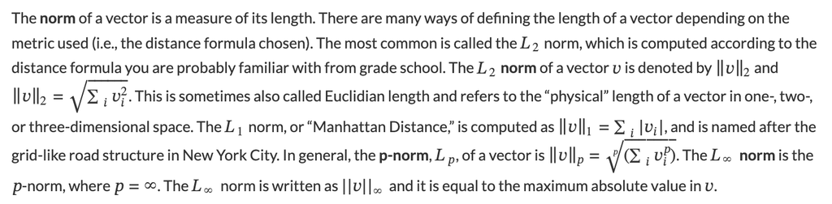

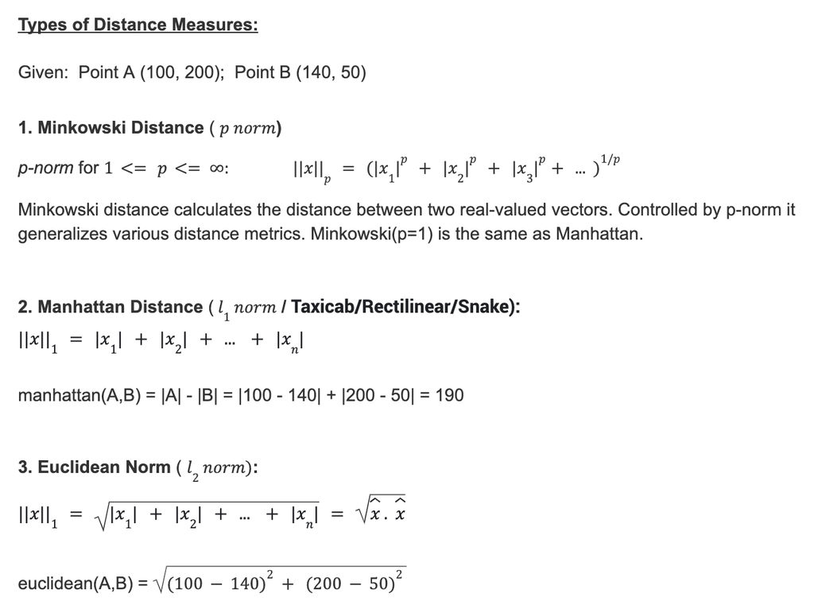

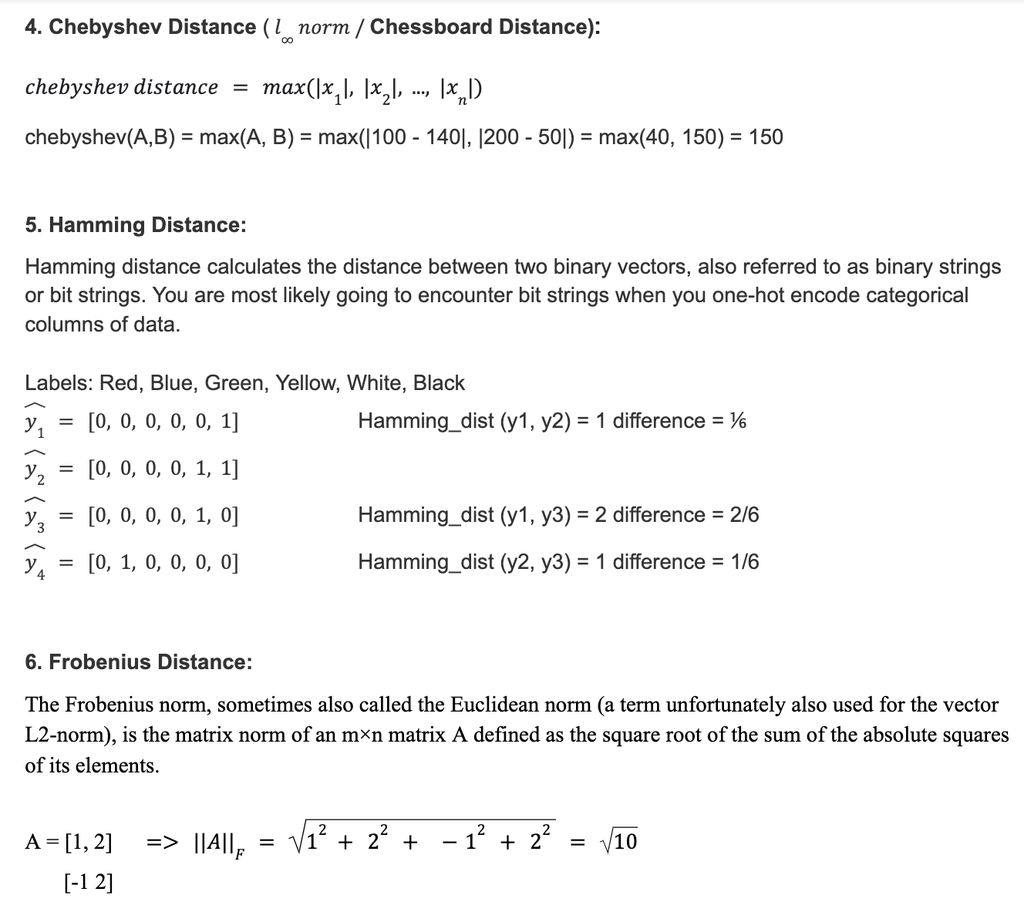

## 3. Numpy Basics

### Importing packages

```python
import numpy as np   # can be anything, 'import numpy as numpaaa'  - you get it 'np' is just an industry acronym.
```

### Array 1

```python
a = np.array(
    [
        [10,4,2],
        [1,6,3]
    ])

a
```

```
array([[10,  4,  2],
       [ 1,  6,  3]])
```

### Array 2

```python
b = np.array([[1,2,3], [4,5,1]])
b
```

```
array([[1, 2, 3],
       [4, 5, 1]])
```

Dimensions of a: 2 Rows x 3 Columns = 2 x 3

Dimensions of b: 2 x 3

### 1. min()

```python
a.min()
```

```
1
```

```python
store = a[0][0]

for i in a:
    for j in i:
        if j < store:
            store = j
store
```

```
1
```

### 2. max()

```python
a.max()
```

```
10
```

```python
store = a[0][0]

for i in a:
    for j in i:
        if j>store:
            store =j
store
```

```
10
```

### 3. mean()

```python
a.mean()
```

```
4.333333333333333
```

```python
sum_, count = 0.0, 0

for row in a:
    for col_value in row:
        sum_ += col_value
        count+=1

sum_/count
```

```
4.333333333333333
```

### 4. argmin()

- axis = 0 : Along the columns
- axis = 1 : Along the rows

```python
print(a)
np.argmin(a, axis = 1)
```

```
[[10  4  2]
 [ 1  6  3]]
```

```
array([2, 0])
```

```python
# Calculating for: argmin(a, axis = 1)
min_list = []

for row in a:
    store = row[0]
    min_index = index = 0

    for j in row:
        if j < store:
            store = j
            min_index = index
        index +=1
    min_list.append(min_index)

min_list
```

```
[2, 0]
```

```python
print(a)
np.argmin(a, axis = 0)
```

```
[[10  4  2]
 [ 1  6  3]]
```

```
array([1, 0, 0])
```

```python
min_list = []

for col in range(len(a[0])):

    store = a[0][col]
    min_index = index = 0

    for row in range(len(a)):
        val = a[row][col]
        if val < store:
            store = val
            min_index = index

        index+=1
    min_list.append(min_index)


min_list
```

```
[1, 0, 0]
```

### 5. argmax()

```python
print(a)
np.argmax(a, axis=1)
```

```
[[10  4  2]
 [ 1  6  3]]
```

```
array([0, 1])
```

```python
max_list = []

for i in a:
    store = i[0]
    index = 0

    for j in i:
        if j >= store:
            store = j
            max_index = index
        index +=1
    max_list.append(max_index)
max_list
```

```
[0, 1]
```

```python
a
```

```
array([[10,  4,  2],
       [ 1,  6,  3]])
```

```python
"""
Intuiton:

Some neural network classifier's probabilistic output values for three labels:

                Label1    Label2    Label3
Output_Unit_1     0.98       0.02      0
Output_Unit_2     0.33       0.33      0.33
Output_Unit_3     0.25       0.50      0.25
Output_Unit_4     0.05       0.45      0.499

How would you extract the 'softmax' output for most probable predicted label? - Use argmax.
"""

arr = np.array([
    [0.98, 0.02, 0],
    [0.33, 0.33, 0.33],
    [0.25, 0.50, 0.25],
    [0.05, 0.45, 0.499]
])
```

```python
class_labels = {0: "Label1", 1: "Label2", 2: "Label3"}
list(map(lambda x: class_labels[x], np.argmax(arr, axis=1)))
```

```
['Label1', 'Label1', 'Label2', 'Label3']
```

### 6. linalg.solve

```python
A = np.array([[1,2],[3,4]])
B = np.array([[10],[20]])

np.linalg.solve(A,B)
```

```
array([[0.],
       [5.]])
```

### 7. flatten

```python
a.flatten()
```

```
array([10,  4,  2,  1,  6,  3])
```

### 8. ravel()

```python
a.ravel()
```

```
array([10,  4,  2,  1,  6,  3])
```

Difference between the Numpy flatten and ravel functions?

- The main functional distinction is that flatten is a function of an ndarray object and hence only works with genuine numpy arrays. ravel(), on the other hand, is a library-level function that may be invoked on any object that can be correctly parsed.

### 9. dot Product

```python
print(a)
print(a.shape)
print("-")
print(b.T)
print(b.T.shape)
```

```
[[10  4  2]
 [ 1  6  3]]
(2, 3)
-
[[1 4]
 [2 5]
 [3 1]]
(3, 2)
```

```python
a.dot(b.T)
```

```
array([[24, 62],
       [22, 37]])
```

```python
np.dot(a, b.T)
```

```
array([[24, 62],
       [22, 37]])
```

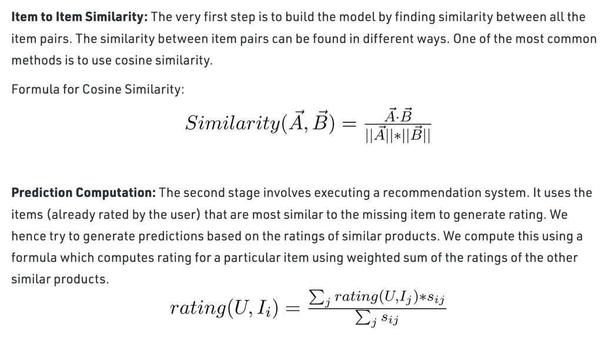

EXTRA READ: https://www.geeksforgeeks.org/item-to-item-based-collaborative-filtering/

### 10. * for

- multiplies each element with corresponding positioned element in another same shape matrix

```python
print(a)
print(a.shape)
print("-")
print(b.T)
print(b.T.shape)
```

```
[[10  4  2]
 [ 1  6  3]]
(2, 3)
-
[[1 4]
 [2 5]
 [3 1]]
(3, 2)
```

```python
np.multiply(a,10)
```

```
array([[100,  40,  20],
       [ 10,  60,  30]])
```

```python
np.multiply(a,b)
```

```
array([[10,  8,  6],
       [ 4, 30,  3]])
```

```python
result_array = ([[0,0,0],[0,0,0]])
a_rows,a_cols = a.shape

for i in range(a_rows):
    for j in range(a_cols):
        result_array[i][j] = a[i][j]*b[i][j]

result_array
```

```
[[10, 8, 6], [4, 30, 3]]
```

### 11. Reshape

```python
k = np.arange(4)
k
```

```
array([0, 1, 2, 3])
```

```python
k.reshape(2,2)
```

```
array([[0, 1],
       [2, 3]])
```

### 12. identity / eye

```python
i_m = np.identity(3)
i_m
```

```
array([[1., 0., 0.],
       [0., 1., 0.],
       [0., 0., 1.]])
```

```python
b = np.empty(i_m.size)


s = 0
i_m_rows, i_m_cols = i_m.shape
for i in range(i_m_rows):
    for j in range(i_m_cols):
        if i == j:
            b[s] = 1
            s += 1
        else:
            b[s] = 0
            s += 1
print("without using inbuilt api diagonal array is\n",b.reshape(3,3))
```

```
without using inbuilt api diagonal array is
 [[1. 0. 0.]
 [0. 1. 0.]
 [0. 0. 1.]]
```

### 13. sum()

```python
a.sum()
```

```
26
```

```python
sum = 0

for i in range(a.size):
    sum += a.item(i)
sum
```

```
26
```

### 14. diag()

```python
k = np.arange(9).reshape(3,3)
k
```

```
array([[0, 1, 2],
       [3, 4, 5],
       [6, 7, 8]])
```

```python
np.diag(k)
```

```
array([0, 4, 8])
```

### 15. tril / triu

```python
np.tril(a)
```

```
array([[10,  0,  0],
       [ 1,  6,  0]])
```

```python
b = np.empty(9)
s = 0
a_rows, a_cols = a.shape
for i in range(a_rows):
    for j in range(a_cols):
        if i < j:
            b[s] = 0
            s += 1
        else:
            b[s] = a[i,j]
            s += 1
print("without using inbuilt api\n",b.reshape(3,3))
```

```
without using inbuilt api
 [[1.000000e+001 0.000000e+000 0.000000e+000]
 [1.000000e+000 6.000000e+000 0.000000e+000]
 [0.000000e+000 1.852187e-317 0.000000e+000]]
```

# Sparse Matrix Operations

There exists various formats in which sparse matrices can be represented. Formats can be divided into two groups:

1. Those that support efficient modification, such as DOK (Dictionary of keys), LIL (List of lists), or COO (Coordinate list). These are typically used to construct the matrices.
1. Those that support efficient access and matrix operations, such as CSR (Compressed Sparse Row) or CSC (Compressed Sparse Column).

`Coordinate list (COO)`

COO stores a list of (row, column, value) tuples. Ideally, the entries are sorted (by row index, then column index) to improve random access times. This is another format which is good for incremental matrix construction

'coo_matrix' is optimized to *construct* a sparse matrix. It is internally different than csr_matrix but when you simply print, it looks same.

`Compressed sparse Row (CSR)`

The compressed sparse row (CSR) or compressed row storage (CRS) format represents a matrix M by three (one-dimensional) arrays, that respectively contain nonzero values, the extents of rows, and column indices. This format allows fast row access and matrix-vector multiplications.

The CSR format stores a sparse m × n matrix M in row form using three (one-dimensional) arrays (A, IA, JA). Let NNZ denote the number of nonzero entries in M. (Note that zero-based indices shall be used here.)

There are **two** types of CS matrices:-

`csr_matrix` considers row first and a `csc_matrix` considers column first.

```
E.g: Let's take a matrix,

mat = [[1, 0, 0],
       [5, 0, 2],
       [0, -1, 0],
       [0, 0, 3]]
```

**csr_matrix** gives the position of non-zero element in the row first then goes to second row, then to third and so on. for instance, csr_matrix(mat) returns:

```
(0, 0)  1.0 -- first row
(1, 0)  5.0 -- second row
(1, 2)  2.0 -- second row
(2, 1)  -1.0 --third row
(3, 2)  3.0 -- fourth row
```

Similarly **csc_matrix** gives the position of non-zero elements in the first column, then second column, and so on.

```
(0, 0)  1.0 -- first column
(1, 0)  5.0 -- first column
(2, 1)  -1.0 -- second column
(1, 2)  2.0 -- third column
(3, 2)  3.0 -- third column
```

Both csr_matrix and csc_matrix are optimized for efficient access, matrix operations such as row/column slicing and vector operations.

Extra Read :

https://rushter.com/blog/scipy-sparse-matrices/

# Week 3 Assignment

## Building Recommender Systems for Movie Rating Prediction¶

Dataset:

```
- Notebook Editor > Module3_USL_v4 > Navigate > Files/home/jovyan/workreleaseModule3data/*
```

```python
"""
DATASET

# 1. "users.csv"
- MV_users == users == data[0]
- Shape: (6040 x 5)
- rows ==> 6040 users
- cols ==> 'User_ID', 'Gender', 'Age', 'Occupation', 'Zip-code'

# 2. "movies.csv"
- MV_movies == movies == data[1]
- Shape: (3883 x 21)
- rows ==> 3883 movies
- cols ==> MID, Title, Year, Genres (Documentry, Comedy, horror, Adventure, Animation, etc)

# 3. "train.csv"
- train == data[2]
- Shape: (700146 x 3)
- rows ==> Rating Value for a (UID, MID)
- cols ==> UID, MID, Rating [(1,2,3,4,5, 1 - lowest rating, 5 - highest rating, 0 - missing value)]

# 4. "test".csv"
- test == data[3]
- Shape: (3883 x 21)
- rows ==> Rating Value for a (UID, MID)
- cols ==> UID, MID, Rating [(1,2,3,4,5, 1 - lowest rating, 5 - highest rating)]
"""
print("Dataset Loaded.")
```

```
Dataset Loaded.
```

# Building Recommender Systems for Movie Rating Prediction

In this assignment, we will build a recommender systems that predict movie ratings. [MovieLense](https://grouplens.org/datasets/movielens/) has currently 25 million user-movie ratings. Since the entire data is too big, we use a 1 million ratings subset [MovieLens 1M](https://www.kaggle.com/odedgolden/movielens-1m-dataset), and we reformatted the data to make it more convenient to use.

### Starter codes

Now, we will be building a recommender system which has various techniques to predict ratings. The `class RecSys` has baseline prediction methods (such as predicting everything to 3 or to average rating of each user) and other utility functions. `class ContentBased` and `class Collaborative` inherit `class RecSys` and further add methods calculating item-item similarity matrix. You will be completing those functions using what we learned about content-based filtering and collaborative filtering.

`RecSys`'s `rating_matrix` method converts the (user id, movie id, rating) triplet from the train data (train data's ratings are known) into a utility matrix for 6040 users and 3883 movies.  
Here, we create the utility matrix as a dense matrix (numpy.array) format for convenience. But in a real world data where hundreds of millions of users and items may exist, we won't be able to create the utility matrix in a dense matrix format (For those who are curious why, try measuring the dense matrix self.Mr using .nbytes()). In that case, we may use sparse matrix operations as much as possible and distributed file systems and distributed computing will be needed. Fortunately, our data is small enough to fit in a laptop/pc memory. Also, we will use numpy and scipy.sparse, which allow significantly faster calculations than calculating on pandas.DataFrame object.  
In the `rating_matrix` method, pay attention to the index mapping as user IDs and movie IDs are not the same as array index.

```python
class RecSys():

    def __init__(self,data):

        # stores everything as a tuple
        self.data=data

        # stores 6040 user IDs (1, 2, 3, ..., 6039, 6040)
        self.allusers = list(self.data.users['uID'])

        # stores 3883 movie IDs (1, 2, 3, ..., 3951, 3952)
        self.allmovies = list(self.data.movies['mID'])
        self.genres = list(self.data.movies.columns.drop(['mID', 'title', 'year']))

        # Stores actual MID: Index MID mapping
        """
        mid2idx --> {Movie_ID: Index}
        {
            MID: Index
            1:    0,
            2:    1,
            3:    2,
            ...
            3951: 3881
            3952: 3882
        }
        """
        self.mid2idx = dict(zip(self.data.movies.mID,list(range(len(self.data.movies)))))

        # Stores actual UID: Index UID mapping
        """
        uid2idx --> {User_ID: Index}
            {
                UID: Index
              1:    0,
                2:    1,
                3:    2,
                ...
                6039: 6038
                6040: 6039
            }
        """
        self.uid2idx = dict(zip(self.data.users.uID,list(range(len(self.data.users)))))

        # Stores User - Movie Rating, using "indexes" instead of actual IDs.
        # 6040 x 3883
        self.Mr = self.rating_matrix()

        # Stores
        self.Mm = None

        # Stores sim scores between all movies, using "indexes" instead of actual IDs.
        # 3883 x 3883
        self.sim = np.zeros((len(self.allmovies),len(self.allmovies)))
        return

    def rating_matrix(self):
        """
        Convert the rating matrix to numpy array of shape (#allusers, #allmovies)

        self.Mr --> Creates a Compressed Sparse Matrix containing mappings of actual User IDs and Movie IDs
                    with usuable IDs. Actual IDs may be alphanumeric or something which may not be visible to
                    the developer, so we need to use self.Mr for accessing IDs.

                    - 6040 users and 3883 movies.
                    - Rows represent users, cols represent movie ratings.
                    - Most of them are zero (could be missing value!).
                    - uid2idx represets actual index of users.

                    E.g.
                    User #2233's ratings are: '[5 0 0 ... 0 0 0]'
                    User #2233 has rated `157` movies!
        """

        # Stores indexes of actual User_IDS, and not the original UID values
        ind_user = [self.uid2idx[x] for x in self.data.train.uID]

        # Stores indexes of actual Movie_IDs, and not the original MID values
        ind_movie = [self.mid2idx[x] for x in self.data.train.mID]

        # Final Rating Matrix (self.Mr)
        # - containing indexes instead of original userIds and MovieIds.
        # - `coo_matrix`: is used to construct a CS matrix for optimized operations.
        rating_train = list(train.rating)
        return np.array(coo_matrix((rating_train, (ind_user, ind_movie)), shape=(len(self.allusers), len(self.allmovies))).toarray())


    def predict_everything_to_3(self):
        """
        Predict everything to 3 for the test data.

        ===> Construct and return a numpy array containing each element as 3.
        HINT: One could use np.ones to construct a numpy array quickly.
        """
        # your code here
        return


    def predict_to_user_average(self):
        """
        Predict to average rating for the user. Returns numpy array of shape (#users,)

        ==> Means we need to compute "average" movie rating for all users provided in self.Mr. We can compute
            the average by taking sum of all ratings for all the users divided by count of **valid** ratings.

            Once we get the average rating for all users, we need to return some of its ratings i.e.
            for Test data Actual UIDs.

        Hint: Remember we have stored "indexes" of actual UIDs and MIDs in self.Mr, so for extracting
              a particular User id from self.Mr we need to provide it's index, `self.uid2idx[Actual_User_ID]`

              Computing sum of a matrix could be easily done using `matrix.sum(axis)`

              The algorithm is:
                  1. Average Rating Computation for all users
                  2. Retireve index of test users from `data.test.uID`
                  3. Compute rating for all test users using Step 1 and 2.
        """
        # your code here
        return


    def predict_from_sim(self,uid,mid):
        """
        Predict a user rating on a movie given userID and movieID

         ==> Means we need to compute average Movie Rating for a given index of UID and index of MovieID.

         Hint: Remember we have stored "indexes" of actual UIDs and MIDs in self.Mr, so for extracting
               a particular User id from self.Mr we need to provide it's index, self.uid2idx[Actual_User_ID].

               Use an example of uid = 2233; mid = 440; to test results.

               Taking just the dot product will yield a Biased Rating matrix since it contains movies which
               were not rated by the user (zeros). To minimise this bias, we should divide this product by
               the count of valid ratings.

               One could utilize np.dot(Matrix, boolean) to count number of valid ratings!

               The algorithm is:
                   1. Get index of the provided user id (index_userID)
                   2. Get all the user ratings for the user using index_userID (ratings_index_userID)
                   3. Get index of the provided movie id (index_movieID)
                   4. Get all the similarity scores using index_movieID (movie_sims)
                   5. Take the **averaged** dot product.

        More on:-
        https://www.geeksforgeeks.org/item-to-item-based-collaborative-filtering/#:~:text=Prediction%20Computation"
        """
        # your code here
        return


    def predict(self):
        """
        Predict ratings in the test data. Returns predicted rating in a numpy array of size (# of rows in testdata,)

        ===> Construct and return a numpy array containing predicted ratings
        HINT: One could use `self.predict_from_sim()` passing every uid and mid from the test data.
        """
        test_preds = []
        for i in range(len(self.data.test)):
            # your code here
        return


    def rmse(self,yp):
        yp[np.isnan(yp)]=3 #In case there is nan values in prediction, it will impute to 3.
        yt=np.array(self.data.test.rating)
        return np.sqrt(((yt-yp)**2).mean())


class ContentBased(RecSys):
    def __init__(self,data):
        super().__init__(data)
        self.data=data
        self.Mm = self.calc_movie_feature_matrix()

    def calc_movie_feature_matrix(self):
        """
        Create movie feature matrix in a numpy array of shape (#allmovies, #genres)

        HINT: Use `self.data.movies` and explore its genres.
        """
        # your code here
        return

    def calc_item_item_similarity(self):
        """
        Create item-item similarity using Jaccard similarity

        self.sim --> all movie similarity scores are stored in this matrix.

                     - A Movie x Movie matrix
                     - 3883 rows and 3883 cols
                     - Each row-col pair represent a similarity score, how similar the movie is.

        Does the super class update self.sim values in the other class?
        Best way to debug this? See it for yourself. Take a small example and check.

        Jaccard similarity Function:
        https://www.statology.org/jaccard-similarity-python/#:~:text=%23define%20Jaccard%20Similarity%20function

        OR,
        self.sim = 1 - pairwise_distances(self.Mm, metric="jaccard")

        """
        # your code here
        return


class Collaborative(RecSys):
    def __init__(self,data):
        super().__init__(data)

    def calc_item_item_similarity(self, simfunction, *X):
        """
        Create item-item similarity using similarity function.
        X is an optional transformed matrix of Mr
        """
        if len(X)==0:
            self.sim = simfunction()
        else:
            # *X passes in a tuple format of (X,), to X[0] will be the actual transformed matrix
            self.sim = simfunction(X[0])

    def cossim(self):
        """
        Calculates item-item similarity for all pairs of items using cosine similarity (values from 0 to 1)
        on utility matrix.

        Returns a cosine similarity matrix of size (#all movies, #all movies)

        Both Boundary checks (Step 5, 7) are important.

        HINT:
        Scope = Movie Ratings Array ==> self.Mr

        userid   movie1  movie2  movie3  movie440 ... movie3883
        user1      0         0        0       0          0
        user2      0         0        0       0          0
        user3      0         0        0       0          0
         ...
        user6040   0         0        0       0          0

        Algorithm:
        1. Compute **averaged** movie ratings for all users (movie_ratings_allUsers)

        2. Create a sparse matrix for operating cosine on its values:
        $:> movie_ratings_array = np.repeat(
                                    np.expand_dims(movie_ratings_allUsers, axis=1), self.Mr.shape[1], axis=1
                                  )

        3. Take care of all the zero ratings (missing value/itentionally we don't know):
        $:> movie_ratings_array_adjusted = self.Mr + (self.Mr==0)*movie_ratings_array - movie_ratings_array

        4. Average all the ratings: divide by its magnitude!
        $:> MR_avg = movie_ratings_array_adjusted/np.sqrt((movie_ratings_array_adjusted**2).sum(axis=0))

        5. Put a Boundary check # 1: since dividing by magnitude may produce inf, zeros, etc. Set nans to 0.

        6. Perform an item-item cosine similarity using: np.dot(matrix.T, matrix)

        7. Put a Boundary check # 2: Covariance/correlation values for np.dot([M.T, M]) matrix should have
           diagonal set to 1. This may cause an autograder issue, so explicilty set diagonals to 1.

        $:> for i in range(len(self.allmovies)):
                item_item_cosine_sim[i, i] = 1

        8. Normalized Cosine Formula:
        -> Check the Resources/Slide Deck M3..
        """
        # your code here
        pass


    def jacsim(self,Xr):
        """
        Calculates item-item similarity for all pairs of items using jaccard similarity (values from 0 to 1)
        Xr is the transformed rating matrix.

        Check Jaccard Distance and Similarity methodology.
        """

        # n = Xr.shape[1]
        # maxr = int(Xr.max())
        # if maxr>1:
        #     intersection = np.zeros((n,n)).astype(int)
        #     for i in range(1, maxr+1):
        #         csr = csr_matrix((Xr==i).astype(int))
        #         intersection = intersection + np.array(csr.T.dot(csr).toarray()).astype(int)

        # Convert Xr into a CSR format
        # csr0 = csr_matrix((Xr>0).astype(int))

        # Take the dot product
        # nz_inter = np.array(csr0.T.dot(csr0).toarray()).astype(int)

        # Formula JS:
        # A = (Xr>0).astype(bool)
        # rowsum = A.sum(axis=0)
        # rsumtile = np.repeat(rowsum.reshape((n,1)),n,axis=1)
        # union = rsumtile.T + rsumtile - nz_inter

        # Perform the two boundary checks:-
        #  - since dividing by magnitude may produce inf, zeros, etc. Set nans to 0.
        #  - Covariance/correlation values for np.dot([M.T, M]) matrix should have
        #    diagonal set to 1.

        # your code here...

        return
        pass
```